# Oblig2-TMA4300

Martine Middelthon

27 2 2020

# Problem B

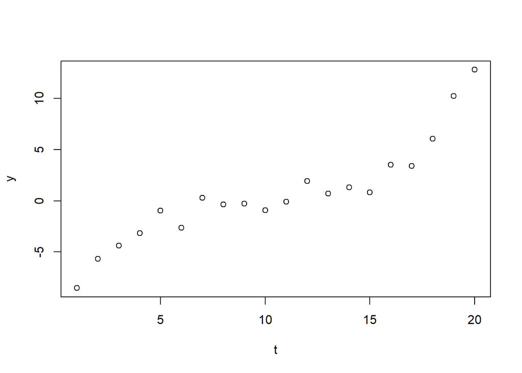

```r
# Read and plot data
gaussiandata = read.delim("gaussiandata.txt")
y = gaussiandata[,1]
t = seq(from=1,to=length(y),by=1)
plot(t,y)
```

## 1.

We consider the problem of smoothing the time series that is plotted above. We assume that given the vector of linear predictors $\boldsymbol\eta=(\eta_1,\ldots,\eta_T)$, where in this case $T=20$, the observations $y_t$ are independent and distributed according to
$$y_t \mid \eta_t \sim \mathcal{N}(\eta_t,1)\quad,$$
for $t=1,\ldots,T$. The linear predictor for time $t$ is $\eta_t = f_t$, where $f_t$ is the smooth effect for time $t$. For the prior distribution of $\mathbf{f}=(f_1,\ldots,f_T)$ we have a second order random walk model, that is,
$$\pi(\mathbf{f}\mid\theta) \propto \theta^{(T-2)/2} \text{exp}\Big\{-\frac{\theta}{2} \sum_{t=3}^T (f_t-2f_{t-1}+f_{t-2}^2) \Big\}=\mathcal{N}(\mathbf{0},\mathbf{Q}(\theta)^{-1}) \quad,$$
where $\mathbf{Q}$ is the precision matrix and $\theta$ is the precision parameter that controls the smoothness of $\mathbf{f}$. We assume that the $Gamma(1,1)$-distribution is the prior for $\theta$.

The model described here can be written as the hierarchichal model:
$$\begin{aligned}
\mathbf{y}\mid\mathbf{f} &\sim \prod_{t=1}^T P(y_t\mid \eta_t) \\
\mathbf{f}\mid\theta &\sim \pi(\mathbf{f}\mid\theta) = \mathcal{N}(\mathbf{0},\mathbf{Q}(\theta)^{-1}) \\
\theta &\sim Gamma(1,1)
\end{aligned}$$
Here, the first line is the likelihood of the response $\mathbf{y}=(y_1,\ldots,y_T)$, the second line gives the prior distribution of the latent field, and the third line gives the prior distribution of the hyperparameter $\theta$. Since our model has this particular structure, it is a latent Gaussian model. INLA can be used to estimate the parameters because we have a latent gaussian model where each data point $y_t$ depends only on the one element $f_t$ in the latent field, the dimension of the hyperparameter is one and the precision matrix $\mathbf{Q}(\theta)$ of the latent field is sparse.

## 2.

Here, we implement a block Gibbs sampling algorithm for $f(\boldsymbol\eta,\theta\mid \mathbf{y})$, where we propose a new value for $\theta$ from the full conditional $\pi(\theta\mid\boldsymbol\eta,\mathbf{y})$ and a new value for $\boldsymbol\eta$ from the full conditional $\pi(\boldsymbol\eta\mid\theta,\mathbf{y})$. Thus, we need to find these distributions. We start with the posterior
$$\pi(\boldsymbol\eta,\theta\mid\mathbf{y}) \propto \pi(\theta) \pi(\boldsymbol\eta\mid\theta) \prod_{t=1}^T\pi(y_t\mid\eta_t,\theta) \propto \frac{\theta^{(T-2)/2}}{(2\pi)^{T/2}} \exp\bigg\{-\theta -\frac{\theta}{2}\sum_{t=3}^T(\eta_t-2\eta_{t-1}+\eta_{t-2})^2 -\frac{1}{2}\sum_{t=1}^T(y_t-\eta_t)^2 \bigg\}.$$
Then we find the full conditional for $\theta$ to be
$$\begin{aligned}
\pi(\theta\mid\mathbf{y},\boldsymbol\eta) &\propto \theta^{T/2-1} \exp\bigg\{-\theta\bigg(1+\frac{1}{2} \sum_{t=3}^T(\eta_t-2\eta_{t-1}+\eta_{t-2})^2\bigg) \bigg\} \\
&\propto \textit{Gamma}\bigg(\frac{T}{2}, 1+\frac{1}{2} \sum_{t=3}^T(\eta_t-2\eta_{t-1}+\eta_{t-2})^2 \bigg)
\end{aligned}.$$
The full conditional for $\boldsymbol\eta$ is
$$\begin{aligned}
\pi(\boldsymbol\eta\mid\theta,\mathbf{y}) &\propto \exp\bigg\{-\frac{\theta}{2} \sum_{t=3}^T(\eta_t-2\eta_{t-1}+\eta_{t-2})^2 -\frac{1}{2}\sum_{t=1}^T(y_t-\eta_t)^2 \bigg\} \\
&= \exp\bigg\{-\frac{1}{2}\bigg(\boldsymbol\eta^T\mathbf{Q}\boldsymbol\eta+ (\mathbf{y}-\boldsymbol\eta)^T(\mathbf{y}-\boldsymbol\eta) \bigg)\bigg\}\\
&= \exp\bigg\{-\frac{1}{2}\boldsymbol\eta^T(\mathbf{Q}+\mathbf{I})\boldsymbol\eta+\mathbf{y}^T\boldsymbol\eta \bigg\}
\end{aligned}.$$
Here, $\mathbf{Q}(\theta)=\theta \mathbf{L}\mathbf{L}^T$ is the precision matrix, where $\mathbf{L}$ is the $T\times (T-2)$ matrix
$$\mathbf{L}=
\begin{bmatrix}
1 & -2 & 1 & 0 & 0 & 0 & \ldots \\
0 & 1 & -2 & 1 & 0 &0&\ldots\\
\vdots & & \ddots &\ddots & \ddots \\
0 & 0 & 0 & 0 & 1 & -2 & 1 \\
0 & 0 & 0 & 0 & 0 & 1 & -2 \\
0 & 0 & 0 & 0 & 0 & 0 & 1
\end{bmatrix}.$$
By looking at the last line in the above expression for $\pi(\boldsymbol\eta\mid\theta,\mathbf{y})$, we recognize that the canonical parametrization is $\mathcal{N}(\mathbf{y}, \mathbf{Q}+\mathbf{I})$, and find that $\pi(\boldsymbol\eta\mid\theta,\mathbf{y}) \propto \mathcal{N}((\mathbf{Q}+\mathbf{I})^{-1}\mathbf{y},(\mathbf{Q}+\mathbf{I})^{-1})$. In the algorithm we sample the new proposals for the parameters from these two distributions that we have found for the full conditionals. We always use the last updated parameters.

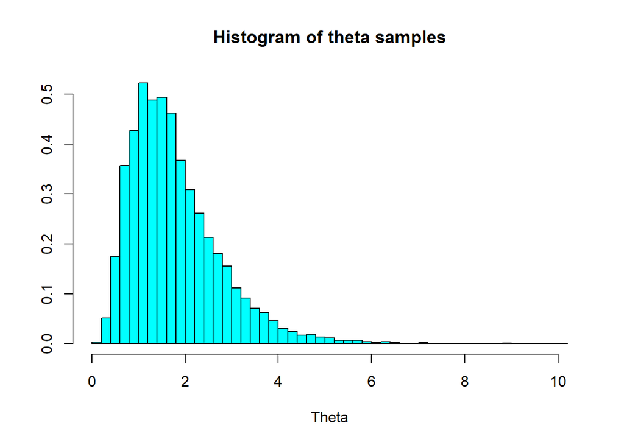

```r
library(Matrix)
library(mvtnorm)
library(MASS)

# Function to make the precision matrix
make.Q = function(T, theta) {
  # Make the matrix L as described in the text
  L = diag(T)
  d1 = rep(-2,T-1)
  d2 = rep(1, T-2)
  L[row(L)-col(L)==1] = d1
  L[row(L)-col(L)==2] = d2
  L = L[,-c(T-1,T)]
  # Compute Q(theta)
  Q = theta * L %*% t(L)
  return(Q)
}

set.seed(0)
# Function for block Gibbs sampling
# n is the number of samples including the inital value
sample.Gibbs = function(n, theta.init, f.init, y) {
  T = length(f.init)
  # Make vector and matrix for storing the samples
  theta.vec = rep(0,n)
  f.matrix = matrix(1:T*n, nrow = T, ncol = n)
  # Initialize
  theta.vec[1] = theta.init
  f.matrix[, 1] = f.init
  # Iterations
  for(i in 2:n) {
    # Sample theta
    summ = 0
    for(t in 3:T) {
      summ = summ + (f.matrix[t, i-1] - 2*f.matrix[t-1, i-1] + f.matrix[t-2, i-1])^2
    }
    theta.vec[i] = rgamma(1, shape = T/2, rate = 1 + 0.5*summ)
    # Sample f
    Q = make.Q(T, theta.vec[i])         # Use the last updated theta
    f.mean = solve(Q+diag(T)) %*% y
    f.sigma = solve(Q+diag(T))
    f.matrix[, i] = rmvnorm(1, f.mean, f.sigma)
  }
  return(rbind(f.matrix, theta.vec))    # Return concatenated matrix with f and theta samples
}

# Set values
n = 10000
T = length(y)
theta.init = 1
f.init = rep(2,T)
# Sample
result = sample.Gibbs(n, theta.init, f.init, y)
result.theta = result[length(result[,1]), -c(1:100)]   # Extracting the theta samples, excluding the first 100 values
result.f = result[-length(result[,1]), -c(1:100)]      # Extracting the f samples, excluding the first 100 values

# Estimate for the posterior marginal for theta
truehist(result.theta, xlab = "Theta", main = "Histogram of theta samples")
```

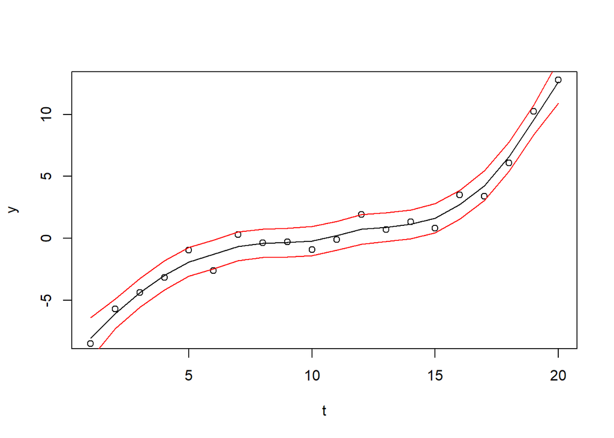

```r
# Vectors for storing the mean, variance and confidence bounds
f.mean = rep(0,T)
f.var = rep(0,T)
conf.upper = rep(0,T)
conf.lower = rep(0,T)
# Calculate the mean and variance
for(t in 1:T) {
  f.mean[t] = mean(result.f[t,])
  f.var[t] = var(result.f[t,])
}
# Calculate 95% confidence bounds
for(t in 1:T) {
  z = qnorm(0.025)
  conf.upper[t] = f.mean[t] + z * sqrt(f.var[t])
  conf.lower[t] = f.mean[t] - z * sqrt(f.var[t])
}
# Plotting
t = seq(from = 1, to = T, by = 1)
plot(t, f.mean, type = "l", ylab = "y")
points(t, y)
lines(t, conf.lower, col = "red")
lines(t, conf.upper, col = "red")
```

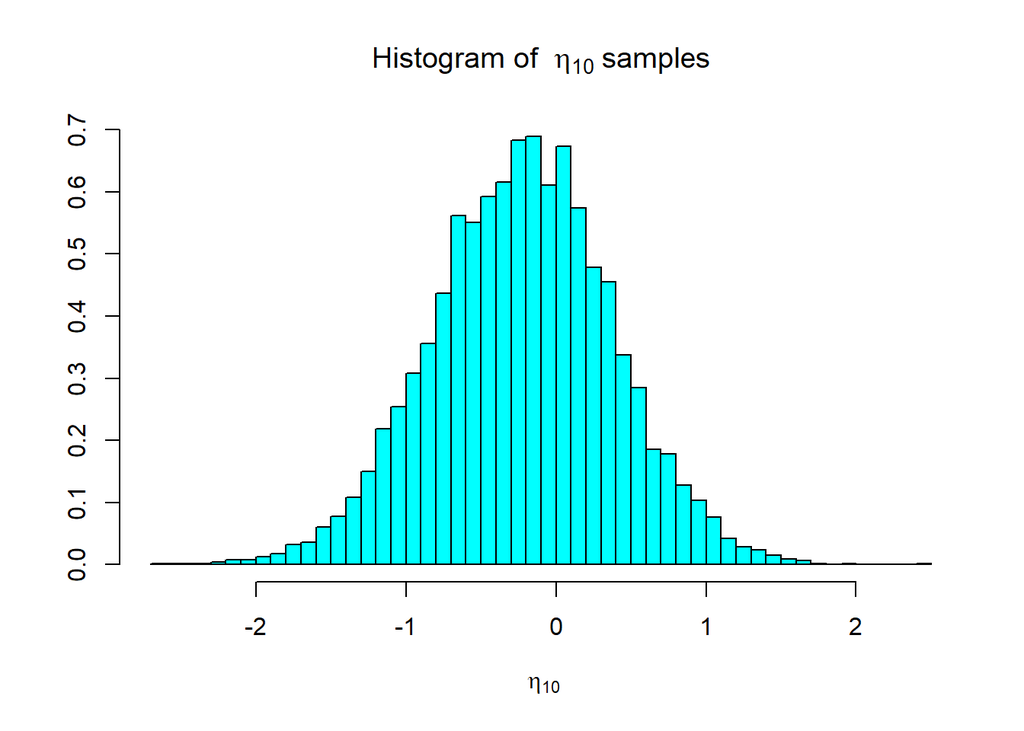

```r
# Estimate of pi(eta_10|y)
f_10 = result.f[10,]
truehist(f_10, xlab = bquote(~eta[10]), main = bquote("Histogram of " ~eta[10]~"samples"))
```

The first histogram shows an estimate for $\pi(\theta\mid\mathbf{y})$. In the plot the data points are plotted as circles. The black line is plotted using the estimates of the smooth effects. The red lines are the $95\%$ confidence bounds. Almost all the data points are within the bounds. The last histogram of the $eta_{10}$ samples provides an estimate of $\pi(\eta_{10}\mid\mathbf{y})$.

## 3.

We want to approximate $\pi(\theta\mid\mathbf{y})$ using the INLA scheme. Since we found that $\pi(\boldsymbol\eta\mid\theta,\mathbf{y}) \propto \mathcal{N}((\mathbf{Q}+\mathbf{I})^{-1}\mathbf{y},(\mathbf{Q}+\mathbf{I})^{-1})$, we can calculate
$$\begin{aligned}
\pi(\theta\mid\mathbf{y}) &\propto \frac{\pi(\mathbf{y}\mid\boldsymbol\eta,\theta)\pi(\boldsymbol\eta\mid\theta)\pi(\theta)}{\pi(\boldsymbol\eta\mid\theta,\mathbf{y})} \\
&\propto \frac{\exp(-\frac{1}{2}(\mathbf{y}-\boldsymbol\eta)^T(\mathbf{y}-\boldsymbol\eta))\theta^{(T-2)/2}\exp(-\frac{1}{2}\boldsymbol\eta^T\mathbf{Q}\boldsymbol\eta)\exp(-\theta)}{|\mathbf{Q}+\mathbf{I}|^{1/2}\exp(-\frac{1}{2}(\boldsymbol\eta-(\mathbf{Q}+\mathbf{I})^{-1}\mathbf{y})^T(\mathbf{Q}+\mathbf{I})(\boldsymbol\eta-(\mathbf{Q}+\mathbf{I})^{-1}\mathbf{y}))} \\
&= \theta^{(T-2)/2}|\mathbf{Q}+\mathbf{I}|^{-1/2}\exp\bigg(-\theta-\frac{1}{2}\mathbf{y}^T\big(\mathbf{I}-(\mathbf{Q}+\mathbf{I})^{-1}\big)\mathbf{y}\bigg)
\end{aligned}\quad,$$
where $|\cdot|$ denotes the determinant and we have used that $|\mathbf{A}^{-1}|=\frac{1}{|A|}$. We use a grid $\boldsymbol\theta_{\text{grid}}$ of values for $\theta$ and calculate the posterior marginal. The plot below shows the result, and it seems to be in concordance with the MCMC estimate displayed by the histogram.

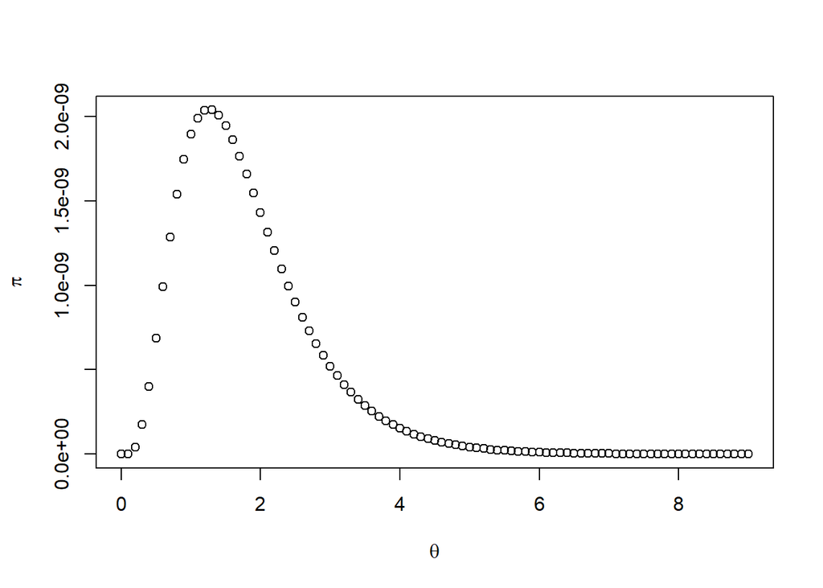

```r
# Function to calculate pi(theta|y) for each theta in the grid
pi_theta_y = function(theta.grid, y) {
  pi = rep(0,length(theta.grid))
  T = length(y)
  for(i in 1:length(pi)){
    theta = theta.grid[i]
    Q = make.Q(T, theta)
    deter = det(solve(Q+diag(T)))
    pi[i] = theta^(T/2-1) * exp(-theta) * deter^(0.5) * exp(-0.5 * t(y) %*% (diag(T)-solve(Q+diag(T))) %*% y)
  }
  return(pi)
}


thetas = seq(from = 0, to = 9, by = 0.1)    # Theta grid
pi = pi_theta_y(thetas, y)                  # Corresponding values for pi(theta|y)
plot(thetas, pi, xlab = bquote(theta), ylab = bquote(pi))   # Plotting
```

```r
#mode = optimise(pi_theta_y,y=y,lower = 0, upper = 9,maximum = TRUE)$maximum
```

## 4.

We also want to implement the INLA scheme for the approximation of $\pi(\eta_i\mid\mathbf{y})$. We have
$$\begin{aligned}
\pi(\eta_i\mid\mathbf{y}) &= \int \pi(\eta_i\mid\mathbf{y},\theta)\pi(\theta\mid\mathbf{y})d\theta \\
&\approx \sum_{\theta_k\in\boldsymbol\theta_{\text{grid}}} \pi(\eta_i\mid\mathbf{y},\theta_k)\pi(\theta_k\mid\mathbf{y}) \Delta
\end{aligned} \quad,$$
where $\boldsymbol\theta_{\text{grid}}$ is the grid of theta values from point 3, and $\Delta$ is the step size between the values in the grid. Since $\pi(\boldsymbol\eta\mid\theta,\mathbf{y}) \propto \mathcal{N}((\mathbf{Q}+\mathbf{I})^{-1}\mathbf{y},(\mathbf{Q}+\mathbf{I})^{-1})$, we assume that $\pi(\eta_i\mid\mathbf{y},\theta)\sim \mathcal{N}([\mathbf{A}\mathbf{y}]_i,\mathbf{A}_{ii})$, where $\mathbf{A}=(\mathbf{Q}+\mathbf{I})^{-1}$. We calculate $\pi(\eta_i\mid\mathbf{y})$ for $i=10$ and values for $\eta_{10}\in[-2,2]$. The plot below shows the result. The graph looks approximately normal with a small and negative mean, which also the estimation obtained using the block Gibbs sampling (displayed by the last histogram in point 2) does.

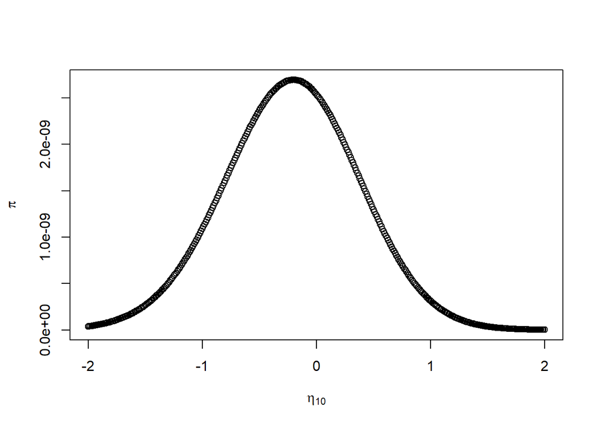

```r
# Function for calculating pi(eta_10|y,theta_k) for each eta_10 in the grid
pi_etai_y_theta = function(etai.grid, theta, y) {
  i = 10
  T = length(y)
  Q = make.Q(T, theta)
  A = solve(Q + diag(T))
  mean = (A %*% y)[i]
  var = A[i,i]
  pi = dnorm(etai.grid, mean = mean, sd= sqrt(var))
  return(pi)    # Return the vector corresponding to each eta_10 in the grid
}

# Function for calculating pi(eta_10|y) for each eta_10 in the grid
pi_etai_y = function(y,theta.grid, eta.grid) {
  sums = rep(0, length(eta.grid))   # Vector for storing the approximations
  step = theta.grid[2]-theta.grid[1]  # Step size
  theta_y = pi_theta_y(theta.grid, y) # vector of pi(theta|y) for each theta in the grid
  for(k in (1:length(theta.grid))) {
    theta = theta.grid[k]             # theta_k
    sums = sums + pi_etai_y_theta(eta.grid, theta, y) * theta_y[k] * step # Adding the terms for theta_k
  }
  return(sums)
}


thetas = seq(from = 0, to = 9, by = 0.1)    # Theta grid
eta.grid = seq(-2,2,0.01)                   # Eta grid
etai_y = pi_etai_y(y,thetas,eta.grid)       # Vector of pi(eta_10|y) for each eta_10 in the grid

plot(eta.grid,etai_y, ylab = bquote(pi), xlab = bquote(eta[10]))    # Plotting the result
```

## 5.

We now use built in inla function for the same estimates as above. In the first figure the estimated smooth effects using inla are plotted as a red line. The MCMC estimates are also plotted in the same figure as a black line. The estimates are very similar, so the lines are overlapping. The second figure shows the estimate of $\pi(\theta\mid\mathbf{y})$, which looks very similar to the ones from point 2 and 3. The last figure shows the estimate for $\pi(\eta_{10}\mid\mathbf{y})$, and it looks like the estimates from point 2 and 4.

```r
library(INLA)
```

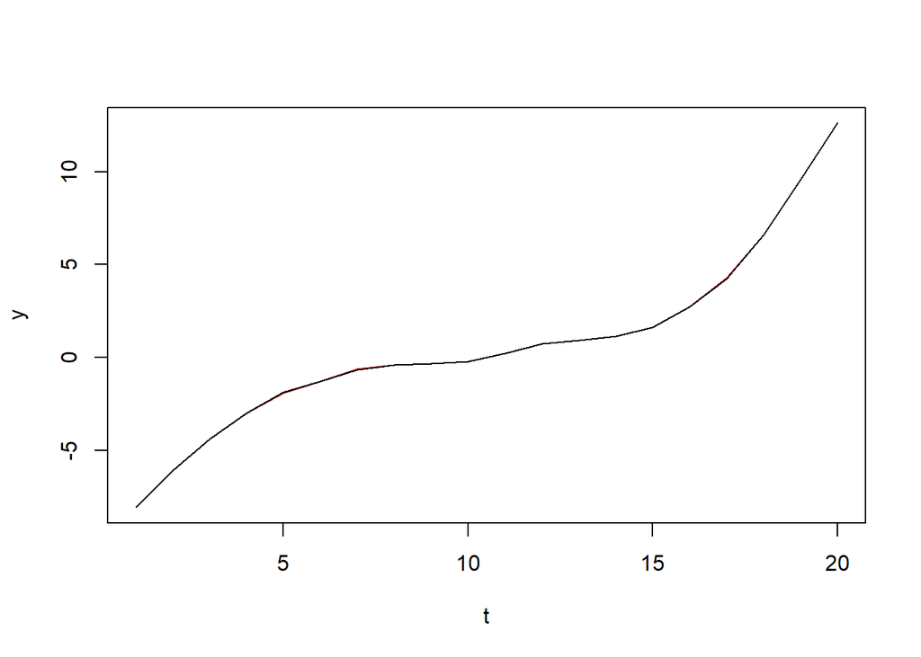

```r
T = 20
t = seq(from = 1, to = T, by = 1)
data = data.frame(y = y, t = t)

thetahyper = list(theta = list(prior = "log.gamma", param = c(1, 1)))
formula = y ∼ f(t, model = "rw2", hyper = thetahyper, constr = FALSE) - 1
result1 = INLA::inla(formula = formula, family = "gaussian", data = data, control.family = list(hyper=list(prec =list(initial=0,fixed=TRUE))))

plot(result1$summary.random$t$mean, xlab="t", ylab="y", type="l", col="red")
lines(t, f.mean)
```

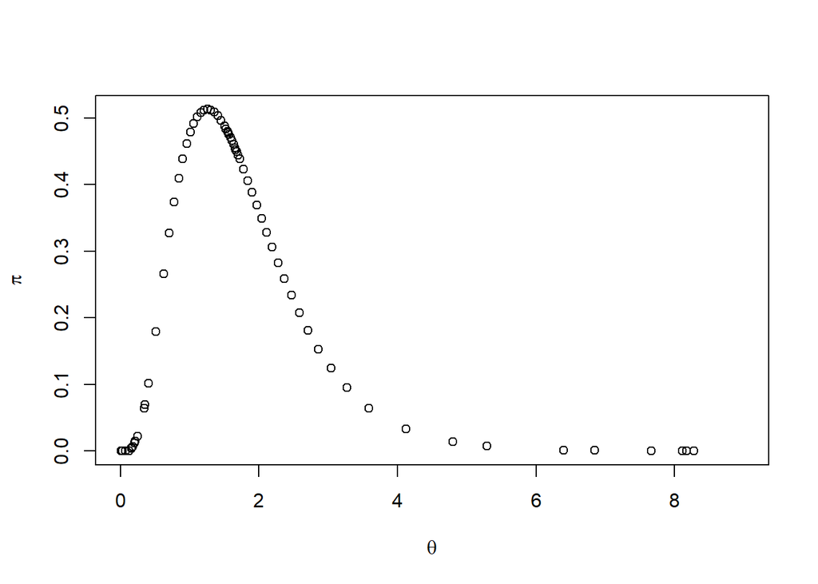

```r
plot(result1$marginals.hyperpar$`Precision for t`, xlim =c(0,9), xlab=bquote(theta),ylab=bquote(pi))
```

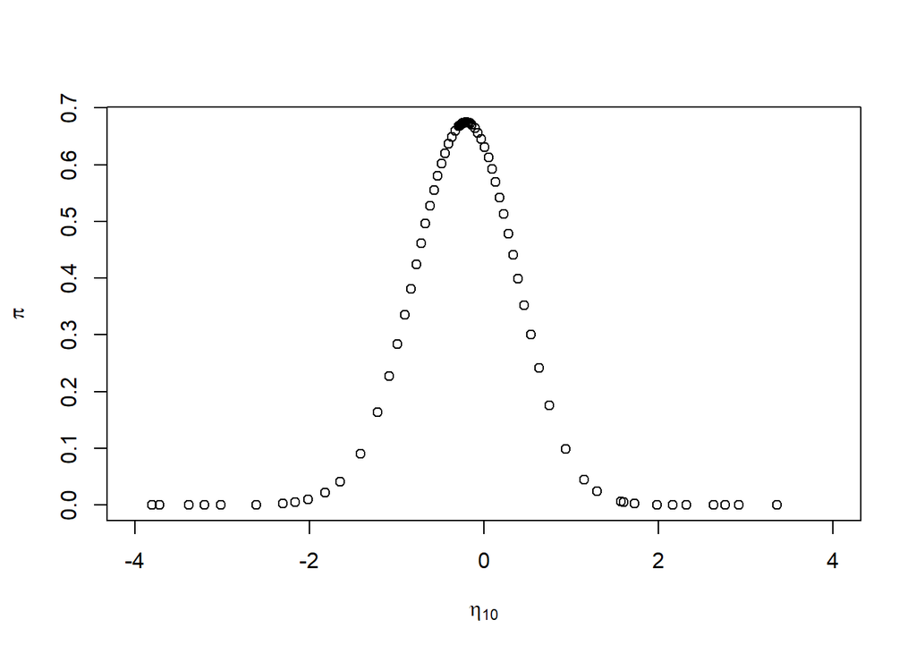

```r
#summary(result1)
plot(result1$marginals.random$t$index.10,xlim=c(-4,4),xlab=bquote(eta[10]),ylab=bquote(pi))
```